# Correlation and Regression

M. E. Perez

February 25, 2016

## Correlation

Population definition:

$\rho_{Y_1Y_2} =\frac{ E\left[(Y_1-E(Y_1))(Y_2-E(Y_2))\right]}{\sigma_{Y_1}\sigma_{Y_2}}$

Sample estimator: $r_{Y_1Y_2} = \frac{\frac{1}{n-1} \sum_{i=1}^n(y_{i1}-\bar{y}_1)(y_{i2}-\bar{y}_2)}{s_{Y_1}s_{Y_2}}$

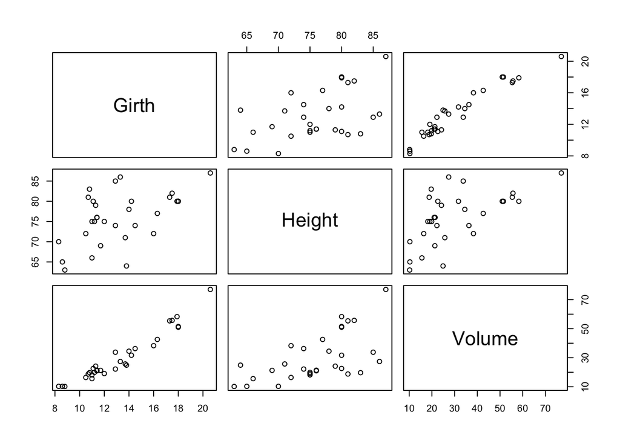

```r
data(trees)
pairs(trees)
```

The graph shows a strong association between Volume and Girth, and some degree of association between Height and Volume. The explanatory variables also seem to be associated.

```r
cor(trees)
```

```
##            Girth    Height    Volume
## Girth  1.0000000 0.5192801 0.9671194
## Height 0.5192801 1.0000000 0.5982497
## Volume 0.9671194 0.5982497 1.0000000
```

## Simple Regression Model

$y_i = \beta_0+\beta_1 x_i + \varepsilon_i, \; \; i=1,\ldots,n$

where $\varepsilon_i \sim N(0,\sigma^2)$

```r
trees.mod1 = lm(Volume~Girth, data=trees)
names(trees.mod1)
```

```
##  [1] "coefficients"  "residuals"     "effects"       "rank"
##  [5] "fitted.values" "assign"        "qr"            "df.residual"
##  [9] "xlevels"       "call"          "terms"         "model"
```

```r
coef(trees.mod1)
```

```
## (Intercept)       Girth
##  -36.943459    5.065856
```

## Tests of Hypothesis on the Parameters of the Model

$H_0: \; \; \beta_i = 0 \; \;\mbox{ vs. } \beta_i \neq 0$

When $H_0$ is true

$t=\frac{\hat{\beta_i}}{\mbox{Standard Error}(\hat{\beta}_i)}\sim t_{n-2}$ (null distribution)

```r
summary(trees.mod1)
```

```
##
## Call:
## lm(formula = Volume ~ Girth, data = trees)
##
## Residuals:
##    Min     1Q Median     3Q    Max
## -8.065 -3.107  0.152  3.495  9.587
##
## Coefficients:
##             Estimate Std. Error t value Pr(>|t|)
## (Intercept) -36.9435     3.3651  -10.98 7.62e-12 ***
## Girth         5.0659     0.2474   20.48  < 2e-16 ***
## ---
## Signif. codes:  0 '***' 0.001 '**' 0.01 '*' 0.05 '.' 0.1 ' ' 1
##
## Residual standard error: 4.252 on 29 degrees of freedom
## Multiple R-squared:  0.9353, Adjusted R-squared:  0.9331
## F-statistic: 419.4 on 1 and 29 DF,  p-value: < 2.2e-16
```

$\hat{\beta}_0$ is negative, and so it can’t be interpreted as the volume of timber when the girth approaches zero!

We reject $H_0: \beta_1=0$ (p-value $< 2 \times 10^{-16}$). The volume of timber can be predicted using the girth as explanatory variable.

## F-test and Multiple determination coefficient $R^2$

The last line of the summary of the model contains the test statistic and the p-value for comparing our model with the model $\mbox{Volume}_i=\beta_0 + \varepsilon_i$. In our example, $F_{1,29}= 419.4$ and $\mbox{p-value}<2.2 \times 10^{-16}$ (lower than the smallest value that can be represented by the computer).

Also in the summary of the model we can find the value of the multiple determination coefficient $R^2$ (a measure of goodness of fit).In our example, $R^2 = 0.9353$, indicating that the model fits well the data.

## Residual plots

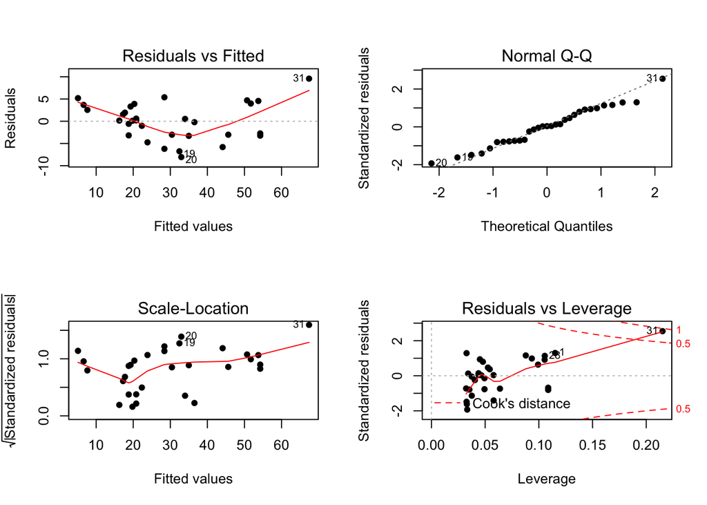

```r
par(mfrow=c(2,2))
plot(trees.mod1,pch=16)
```

- The residuals vs fitted values plot has a curved form (positive residuals in the extremes, negative residuals at the center). This suggests that we should adjust a different model with higher order terms.
- Observation 31 is an influential observation, and it seems to be an outlier with respect to the model (an observation with an unusually large residual)

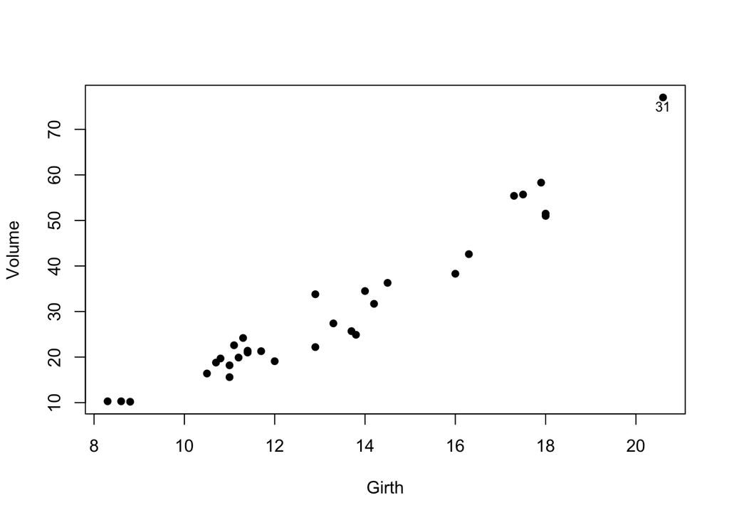

```r
par(mfrow=c(1,1))
with(trees,plot(Girth,Volume,pch=16))
with(trees,text(Girth[31],Volume[31]-2,labels="31",cex=0.8))
```

# Multiple linear regression

```r
trees.mod2=lm(Volume~Girth+I(Girth^2)+Height,data=trees)
summary(trees.mod2)
```

```
##
## Call:
## lm(formula = Volume ~ Girth + I(Girth^2) + Height, data = trees)
##
## Residuals:
##     Min      1Q  Median      3Q     Max
## -4.2928 -1.6693 -0.1018  1.7851  4.3489
##
## Coefficients:
##             Estimate Std. Error t value Pr(>|t|)
## (Intercept) -9.92041   10.07911  -0.984 0.333729
## Girth       -2.88508    1.30985  -2.203 0.036343 *
## I(Girth^2)   0.26862    0.04590   5.852 3.13e-06 ***
## Height       0.37639    0.08823   4.266 0.000218 ***
## ---
## Signif. codes:  0 '***' 0.001 '**' 0.01 '*' 0.05 '.' 0.1 ' ' 1
##
## Residual standard error: 2.625 on 27 degrees of freedom
## Multiple R-squared:  0.9771, Adjusted R-squared:  0.9745
## F-statistic: 383.2 on 3 and 27 DF,  p-value: < 2.2e-16
```

It is not advisable to remove more than one variable at a time using the t-test, as the t-test only allows to compare models differing in one variable.

## Analysis of variance

```r
trees.mod0 = lm(Volume ~ 1, data=trees)
summary(trees.mod0)
```

```
##
## Call:
## lm(formula = Volume ~ 1, data = trees)
##
## Residuals:
##     Min      1Q  Median      3Q     Max
## -19.971 -10.771  -5.971   7.129  46.829
##
## Coefficients:
##             Estimate Std. Error t value Pr(>|t|)
## (Intercept)   30.171      2.952   10.22 2.75e-11 ***
## ---
## Signif. codes:  0 '***' 0.001 '**' 0.01 '*' 0.05 '.' 0.1 ' ' 1
##
## Residual standard error: 16.44 on 30 degrees of freedom
```

```r
anova(trees.mod0,trees.mod1)
```

```
## Analysis of Variance Table
##
## Model 1: Volume ~ 1
## Model 2: Volume ~ Girth
##   Res.Df    RSS Df Sum of Sq      F    Pr(>F)
## 1     30 8106.1
## 2     29  524.3  1    7581.8 419.36 < 2.2e-16 ***
## ---
## Signif. codes:  0 '***' 0.001 '**' 0.01 '*' 0.05 '.' 0.1 ' ' 1
```

The F-statistic and the p-value are the ones in the summary of the model.

## Confidence intervals and prediction intervals

We will work with a “mean” tree.

```r
with(trees,c(mean(Girth),mean(Height)))
```

```
## [1] 13.24839 76.00000
```

Confidence interval for a “mean” tree.

```r
predict(trees.mod1,data.frame(Girth=13.25,Height=76),interval="confidence")
```

```
##        fit      lwr      upr
## 1 30.17914 28.61724 31.74104
```

Prediction interval for a “mean” tree.

```r
predict(trees.mod1,data.frame(Girth=13.25,Height=76),interval="prediction")
```

```
##        fit     lwr      upr
## 1 30.17914 21.3437 39.01458
```